# modelado_validacion

JMason88

14 de octubre de 2018

# Limpio Memoria

```r
rm(list = ls())
```

# Llamo librerías

```r
library(tidyr)
library(tidyverse)
```

```r
library(ggplot2)
library(readr)
library(cluster)
library(factoextra)
library(NbClust)
```

Levanto primera version de pre-procesamiento.

```r
hip1 <- read_csv("../02.Preprocesamiento/hip_version1.csv")
```

Análisis de tendencia de clusterización ¿existen indicios para pensar que este dataset podría ser clusterizable?

Grafico PCA para ver posicionamiento de la Hyades

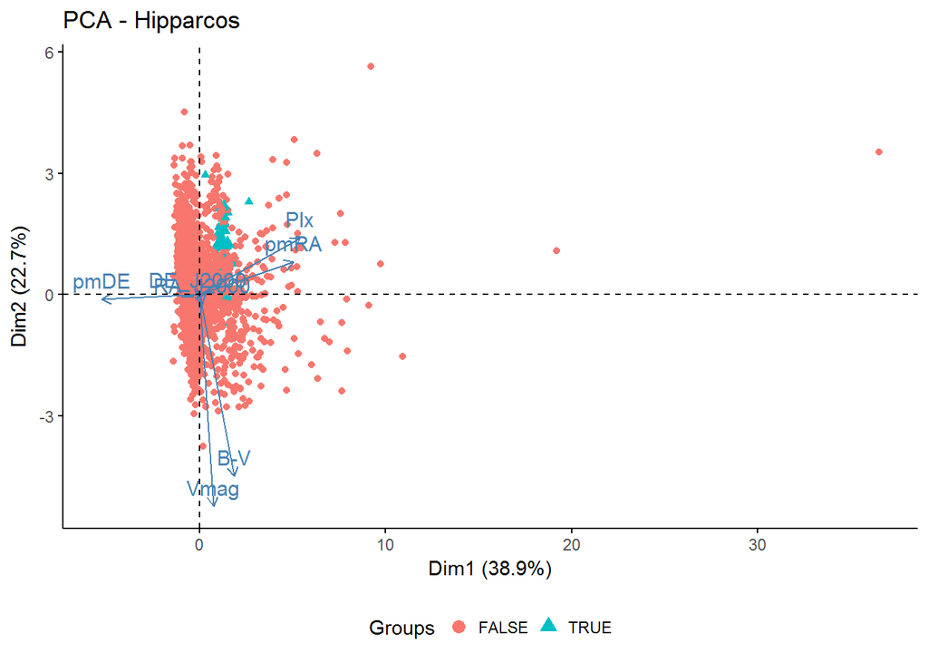

```r
library(ggsci)
fviz_pca(prcomp(hip1[,-c(1,9)]), title = "PCA - Hipparcos",
             habillage = hip1$Symbad_Hyades,  palette = "uchicago",
             geom = "point", ggtheme = theme_classic(),
             legend = "bottom")
```

A través del gráfico de PCA se puede observar que las Hyades se encuentran concentradas.

A continuación se procederá a hacer un análisis de tendencia a la clusterización del conjunto de datos. Para esto se utilizará la función “get_clust_tendency” que tiene implementado el cálculo del estadístico de Hopkins.

```r
set.seed(123)

gradient.color <- list(low = "steelblue",  high = "white")

hip1 %>%
  select(., -HIP, -Symbad_Hyades) %>%
  get_clust_tendency(n=nrow(.)-1, gradient = gradient.color) #Ojo que tarda mucho con n-1 grados de libertad
```

```
## $hopkins_stat
## [1] 0.04847422
##
## $plot
```

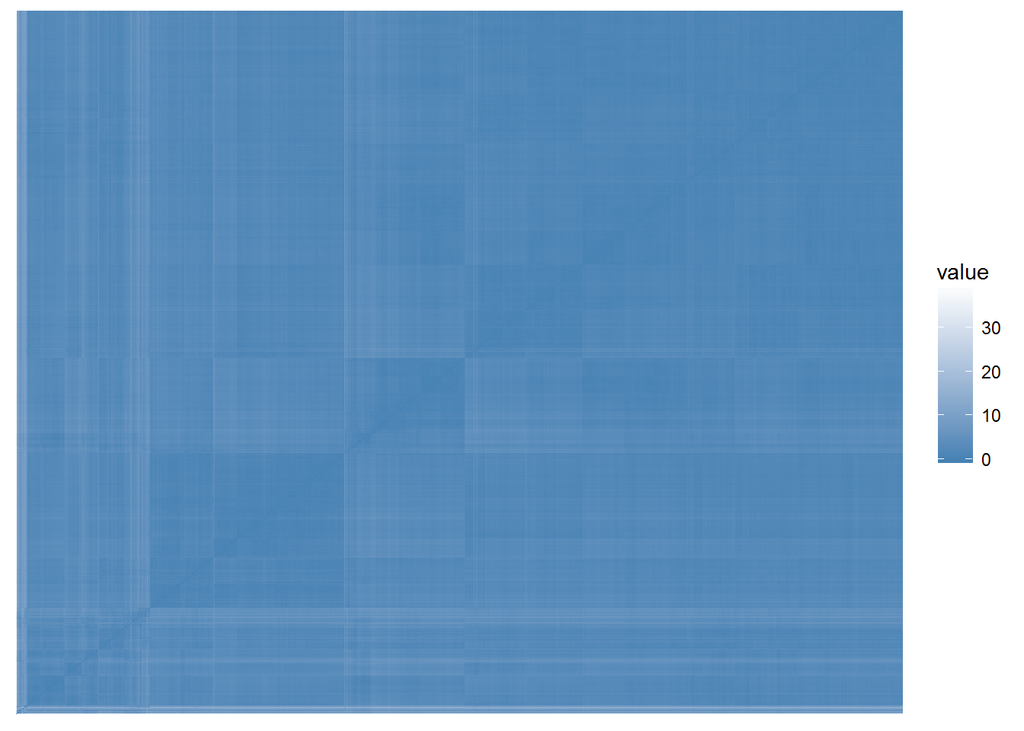

El estadístico de Hopkins parecería indicar que este conjunto no es clusterizable, ya que su valor es cercano a 0. (Un conjunto con fuerte tendencia a la clusterización debería tener un estadístico >0.5)

Sin embargo para este caso no queremos clusterizar perfectamente todo el dataset. Solamente nos interesa clusterizar las hyades.

A continuación realizará el análisis de Cluster tomando dos métodos distintos: -Kmeans (o K-medias) -PAM (Partition around Medoids)

## Analisis utilizando K-medias

Para el análisis de K-medias se llamará a la librería NbClust que cuenta con un método de validación por votación a partir del cálculo de 30 índices y métricas distintas de ajuste de los clústers, para determinar cual debería ser la cantidad adecuada de k a utilizar.

Como la función NbClust de su librería original poseía ciertas restricciones respecto a la cantidad de parámetros que se pueden pasar al algoritmo Kmeans, se generó una función auxiliar “NbClust2” a partir del código fuente original de la librería. Con esta pequeña modificación se puedo extender la cantidad iteraciones máximas posibles del K-medias hasta hallar la convergencia.

```r
source("NbClust2_kmeans.r")
kmeans_euclid <- NbClust2(data = hip1[,-c(1,9)], min.nc = 2, max.nc = 10, method = "kmeans", index = "all", max.iter = 25)
```

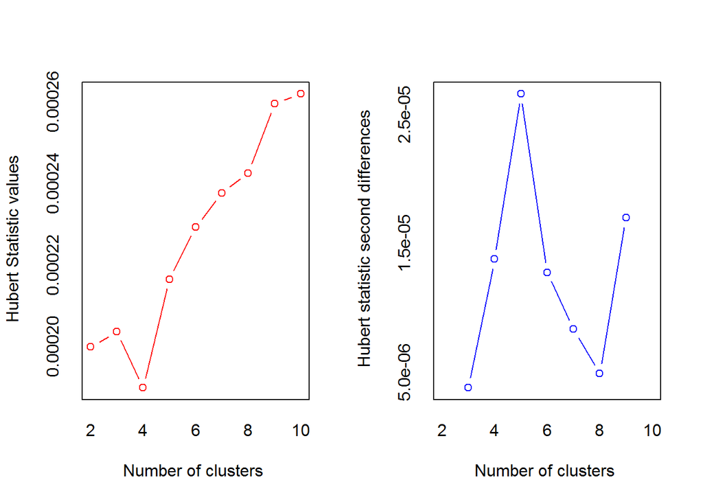

```
## *** : The Hubert index is a graphical method of determining the number of clusters.
##                In the plot of Hubert index, we seek a significant knee that corresponds to a
##                significant increase of the value of the measure i.e the significant peak in Hubert
##                index second differences plot.
##
```

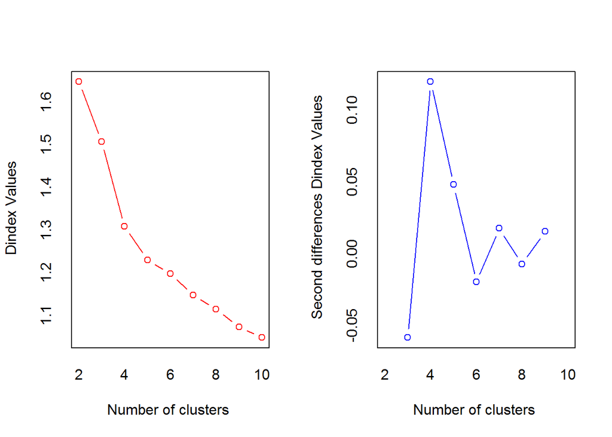

```
## *** : The D index is a graphical method of determining the number of clusters.
##                In the plot of D index, we seek a significant knee (the significant peak in Dindex
##                second differences plot) that corresponds to a significant increase of the value of
##                the measure.
##
## * Among all indices:
## * 7 proposed 2 as the best number of clusters
## * 3 proposed 3 as the best number of clusters
## * 5 proposed 4 as the best number of clusters
## * 2 proposed 5 as the best number of clusters
## * 1 proposed 8 as the best number of clusters
## * 3 proposed 9 as the best number of clusters
## * 3 proposed 10 as the best number of clusters
##
##                    ***** Conclusion *****
##
## * According to the majority rule, the best number of clusters is  2
##
##
```

```r
kmeans_euclid
```

```
## $All.index
##         KL       CH Hartigan     CCC     Scott      Marriot    TrCovW
## 2   0.1404 602.4670 495.5540 -2.4662  7046.212 5.406362e+21 3794386.5
## 3   0.9916 605.3683 403.4911 -2.1778  9356.936 5.069448e+21 2726011.7
## 4   0.9248 599.6006 375.5245  3.4604 12206.506 3.062446e+21 2142956.5
## 5   1.6323 607.4154 268.8024 13.6504 13828.476 2.588603e+21 1562653.2
## 6   4.9187 589.0402 144.6310 20.2771 14925.347 2.460291e+21 1161622.9
## 7   3.8406 541.7194  95.6763 21.5633 15596.752 2.596752e+21 1064491.8
## 8   0.0185 494.6836 506.2483 19.2007 16284.641 2.613682e+21 1010967.3
## 9   8.0225 579.1646 133.0806 42.0852 18232.899 1.581462e+21  650154.5
## 10 44.1580 555.4287  71.4144 43.3001 18997.746 1.461343e+21  592076.5
##       TraceW Friedman  Rubin Cindex     DB Silhouette   Duda  Pseudot2
## 2  11098.052   7.8043 1.3452 0.0539 1.9037     0.4314 1.0221  -54.8359
## 3   9342.957   8.9905 1.5979 0.0506 1.6689     0.2163 0.6651  864.0180
## 4   8103.092  11.7637 1.8424 0.0419 1.5126     0.2568 1.4584 -538.4631
```

[output cut: 132 more lines]

De todos los índice y métricas que el NbClust corrió, 7 de ellos propusieron 2 clústers como la partición que mejor ajusta a los datos.

A continuación se guarda el modelo de K-medias para k=2 y se procede a graficar la proyección de los clúster en los ejes de las componentes principales.

```r
set.seed(1)
hip_kmeans_final <- hip1 %>% select(., -c(1,9)) %>% kmeans(., 2)


hip_kmeans_clust1 <- cbind(hip1, kmeans_clust = hip_kmeans_final$cluster)
table(Symbad = hip_kmeans_clust1$Symbad_Hyades, Cluster = hip_kmeans_clust1$kmeans_clust)
```

```
##        Cluster
## Symbad     1    2
##   FALSE 2275  315
##   TRUE     1   49
```

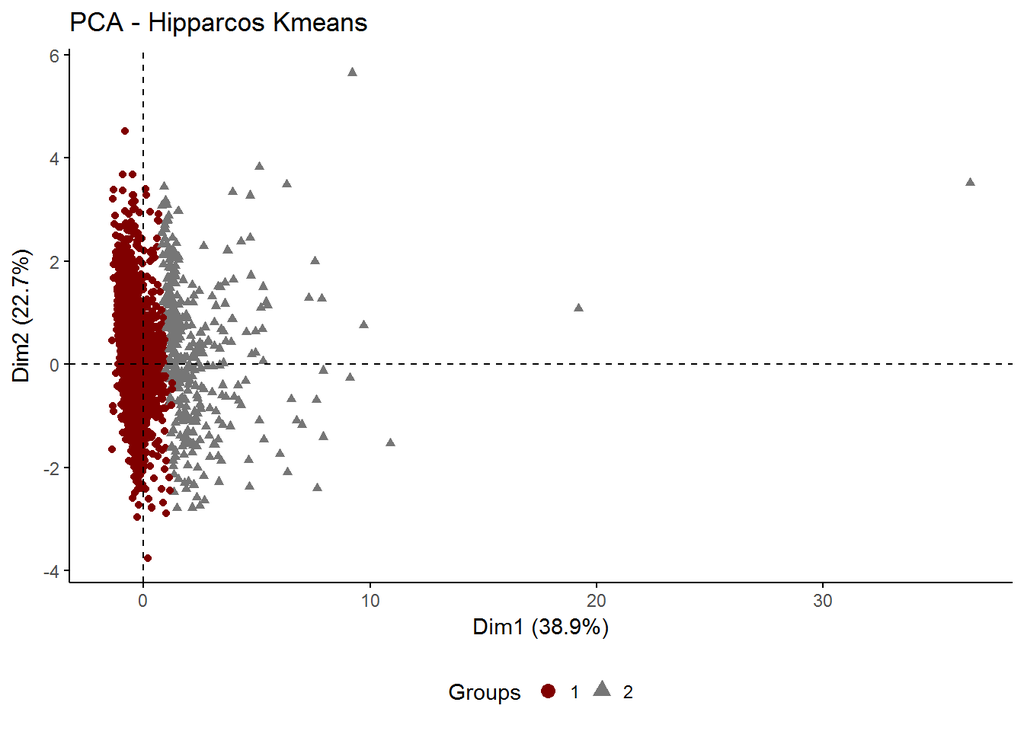

```r
fviz_pca_ind(prcomp(hip_kmeans_clust1[,-c(1,9,10)]),
                title = "PCA - Hipparcos Kmeans",
                habillage = hip_kmeans_final$cluster,
                palette = "uchicago",
                geom = "point",
                ggtheme = theme_classic(),
                legend = "bottom", axes = c(1,2))
```

De los resultados del Kmeans se extrae que de la clusterización, 49 Hyades han sido clasifciadas dentro de un mismo clúster: el número 2. Dentro del cluster número 2 han sido agrupadas otras 315 estrellas que podrían resultar en potenciales candidatas a formar parter del clúster de estrellas Hyades.

Sin embargo, convendría detenerse en ese clúster puntual y analizar los resultados de Silhoutte hacia dentro de ese clúster.

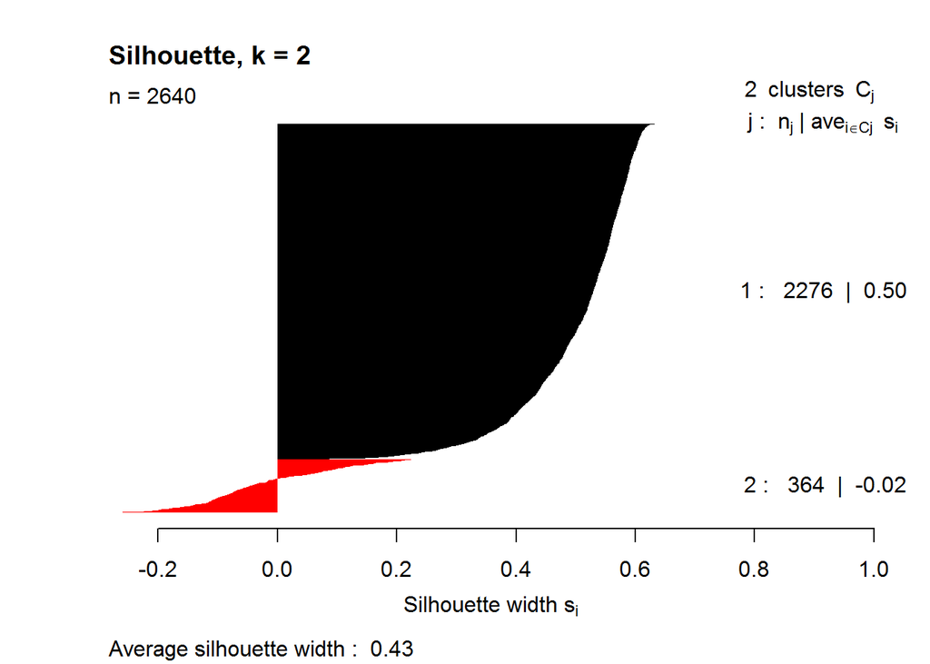

```r
sil_kmeans_final <- silhouette(hip_kmeans_final$cluster, dist(hip1[,-c(1,9)], method = "euclidian"))

plot(sil_kmeans_final, main="Silhouette, k = 2",col=1:2 ,border = NA)
```

De observar el gráfico de Silhouette, surge que del clúster número 2, no todas las estrellas parecerían ser similares hacia dentro del clúster. De hecho, parecería ser que un poco mas de la mitad de ellas debería pertencer al clúster 1 en vez del clúster 2.

```r
hip_kmeans_clust1 <- hip_kmeans_clust1 %>% cbind(.,
                                                 sil_clust = sil_kmeans_final[,1],
                                                 sil_neigh = sil_kmeans_final[,2],
                                                 sil_width = sil_kmeans_final[,3]
                                                 )
```

```r
hip_kmeans_clust1 %>% filter(., sil_clust == 2) %>% select(., -c(1:8,10:12))
```

```
##     Symbad_Hyades     sil_width
## 1           FALSE -0.0158482897
## 2           FALSE -0.1417039411
## 3           FALSE  0.2075781595
## 4           FALSE  0.1637875623
## 5           FALSE  0.0669168997
## 6           FALSE -0.0875441155
## 7           FALSE  0.1935390497
## 8           FALSE -0.1136069588
## 9            TRUE  0.1475404545
## 10          FALSE  0.1894515126
## 11          FALSE -0.1307440899
## 12          FALSE  0.1531537064
## 13          FALSE -0.0029456351
## 14          FALSE -0.0673838051
```

[output cut: 350 more lines]

Con lo cual es probable que el clúster hasta acá aqui analizado posea algún grupo de estrellas no compatible con las características de la Hyades o mucho mas cercanas entre sí que las Hyades mismas.

Por último se procederá a guardar los resultados finales como checkpoint del trabajo hasta aqui realizado en una salida de CSV.

```r
write_csv(hip_kmeans_clust1, "hip_kmeans_clust1.csv")
```

-Análisis PAM (Partition Around Medoids)

```r
source('PAM_loop.r')
```

-Distancia Euclídea

```r
diss_euclid_hip <-hip1[,2:8] %>% dist(., method = "euclidian")


PAM_HIP_Euclid <- PAM_loop(diss_euclid_hip, hip1[,2:8], 20)
```

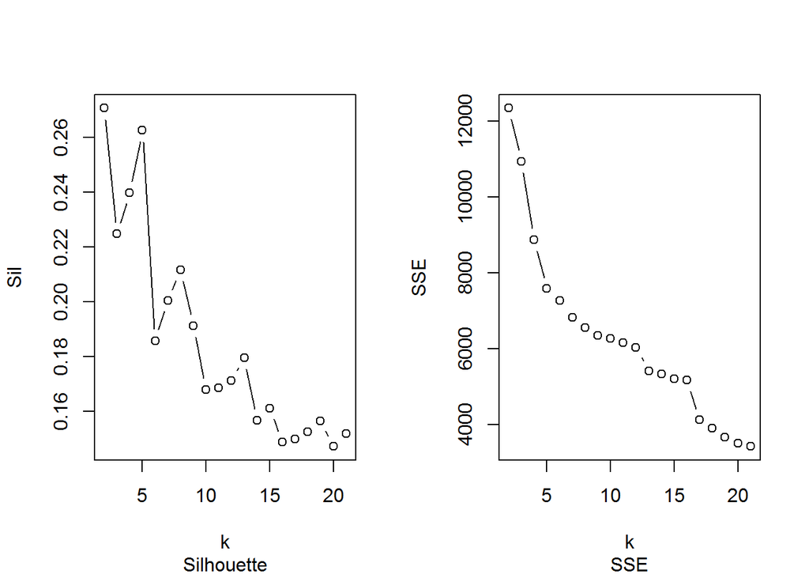

```r
SSE <- PAM_HIP_Euclid[[1]]
Sil <- PAM_HIP_Euclid[[2]]
par(mfrow=c(1,2))
plot(2:(21), Sil , type="b", xlab="k", sub="Silhouette")
plot(2:(21), SSE , type="b", xlab="k", sub = "SSE")
```

EL resultado de Silhouette parecería indicar que 2 o 5 clústers podrían ser el número adecuado de k.

# Analisis PAM para K=2

```r
PAM_HIP_Euclid_k2 <- pam(diss_euclid_hip, 2, diss = T)


hip_pam_clustk2 <- cbind(hip1, PAM_clust = PAM_HIP_Euclid_k2$clustering)

#######         Hyades vs Cluster analysis

table(Symbad = hip_pam_clustk2$Symbad_Hyades, Cluster = hip_pam_clustk2$PAM_clust)
```

```
##        Cluster
## Symbad     1    2
##   FALSE 1832  758
##   TRUE    45    5
```

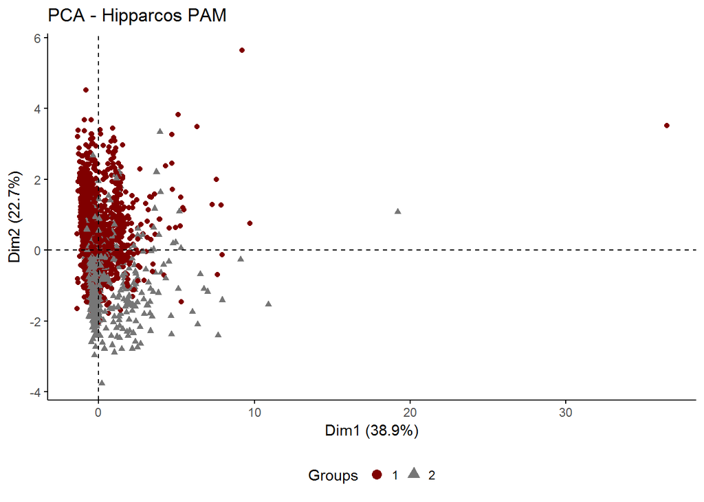

```r
#######         PCA

fviz_pca_ind(prcomp(hip_pam_clustk2[,-c(1,9,10)]),
                title = "PCA - Hipparcos PAM",
                habillage = hip_pam_clustk2$PAM_clust,
                palette = "uchicago",
                geom = "point",
                ggtheme = theme_classic(),
                legend = "bottom", axes = c(1,2))
```

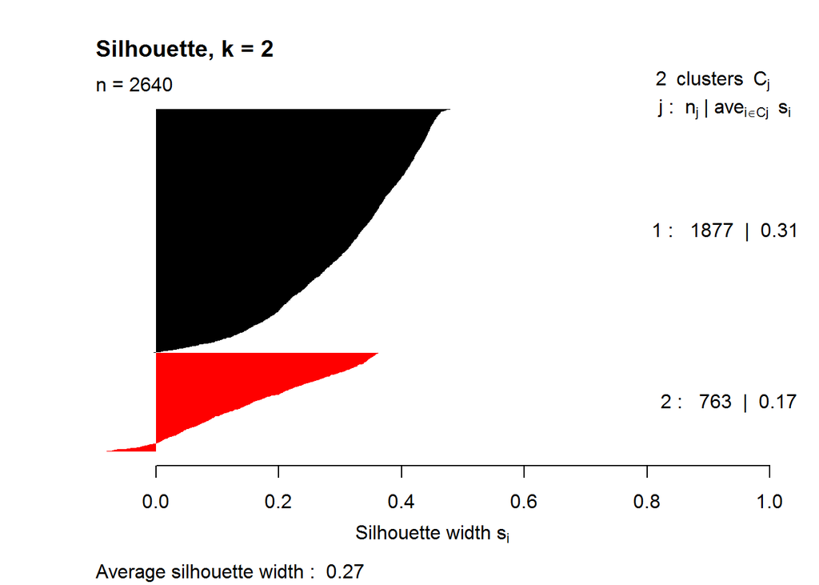

```r
#######         Silhouette

sil_pamk2_final <- silhouette(hip_pam_clustk2$PAM_clust, diss_euclid_hip)

plot(sil_pamk2_final, main="Silhouette, k = 2",col=1:2 ,border = NA)
```